# Beyond MLR Lab 1: Modeling center as a fixed effect

Model answers · Week 1

# A multicenter rehabilitation trial

We return to the rehabilitation trial from the lecture. In this simulated study, 120 patients recovering from knee replacement receive either **standard care** or an **enhanced rehabilitation program**. Standard care consists of weekly physiotherapy and home exercises; enhanced care adds a weekly supervised session. The outcome is the distance walked during a six-minute walk test at 12 weeks, measured in meters. A larger distance indicates better walking performance.

The study includes six centers. Within each center, 10 patients are randomly assigned to standard care and 10 to enhanced care. This is a **randomized block design**, with center as the blocking factor. These are simulated teaching data.

Our question is: **What is the estimated difference in expected walking distance between enhanced and standard care, and how precisely is it estimated?** We will explore differences between centers and fit a model that includes center as a fixed effect.

By the end of this lab, you should be able to visualize treatment and center differences, fit and interpret the fixed-effects model, quantify uncertainty about the treatment effect, and check the model assumptions.

**NoteWorking through the lab**

Run the code in order in an R script, and record your answers to the questions. The lab page shows the code; you generate the results yourself.

# Organize your work

## Use one folder per week

Create a folder for this course, with a separate folder for each week. Keep that week’s lab scripts and data together so that you can find and rerun your analyses when working on the assignment. For Week 1, use the following structure:

```
BeyondMLR/
  week1/
    lab1.R
    lab2.R
    data/
      rehabilitation_week1.csv
  week2/
```

Create the `week1` folder and its `data` subfolder now. Download the rehabilitation dataset and save it in `week1/data`. Keep the filename unchanged.

## Save your code in an R script

An **R script** is a text file with the extension `.R` that records the commands for your analysis. Saving your code lets you repeat the analysis in a new R session and adapt it later.

In RStudio, select **File > New File > R Script** and save the file as `lab1.R` inside `week1`. Copy the R code from this lab into your script as you work through it. Place the cursor on a line, or select several lines, and click **Run** to execute them in the Console. The shortcut is **Ctrl+Enter** on Windows/Linux or **Cmd+Enter** on macOS. Run the code in order, starting with package loading and data import. [RStudio’s code-editing guide](https://docs.posit.co/ide/user/ide/get-started/) describes these controls.

Add comments beginning with `#` to explain your code and record short answers to the lab questions. Save the script regularly.

## Set the working directory

The **working directory** is the folder R uses as the starting point for relative file paths. For example, `"data/rehabilitation_week1.csv"` tells R to look inside the `data` subfolder of its working directory. Relative paths used to save output also start from this folder.

For this lab, set the working directory to `week1`, which contains your script and the `data` folder. Set the working directory explicitly when starting your analysis.

**NoteChanging the working directory in RStudio**

Select **Session > Set Working Directory > Choose Directory…**, then choose your `week1` folder. Alternatively, with the saved `lab1.R` script active, select **Session > Set Working Directory > To Source File Location**.

Run `getwd()` in the Console to check the selected folder. It should be `week1`. Check this again when starting a new session. These controls are part of [RStudio’s working-directory tools](https://support.posit.co/hc/en-us/articles/200711843-Working-Directories-and-Workspaces-in-the-RStudio-IDE).

# Setup and data

## Install pak once

An R **package** provides additional functions, for example for drawing figures or fitting statistical models. Throughout this course, we will use the package manager **pak** to install the packages we need. It also handles their **dependencies**: other packages they need to work.

First, install `pak` itself by running the following command in the Console. You only need to do this once for your current R installation; skip this step if you already have `pak` installed.

```r
install.packages("pak", repos = "https://cloud.r-project.org")
```

## Use pak throughout the course

**Installing** a package saves it on your computer. **Loading** a package makes its functions available in the current R session. Installed packages remain available between sessions, but you need to load them again when you start a new session.

We will follow the same pattern in each lab: load `pak` with `library(pak)`, use `pkg_install()` to install the packages needed for that lab, and then load those packages with `library()`. The [pak package manager](https://pak.r-lib.org/reference/pkg_install.html) checks the required packages and their dependencies and keeps already installed versions when they meet the requirements.

For this lab, we need `ggplot2` for figures and `dplyr` for summaries. Add the following code to the beginning of your script and run it. If `pak` asks whether to proceed, confirm the installation and wait for it to finish.

```r
library(pak)
pkg_install(c("ggplot2", "dplyr"))
```

Now load the packages for your analysis. Keep these commands in your script so that they run each time you start the lab in a new R session.

```r
library(ggplot2)
library(dplyr)
```

## Read the data

With `week1` as your working directory and the dataset saved in its `data` subfolder, run the following code. If R cannot find the file, check `getwd()`, the folder containing the CSV file, and its filename.

```r
rehab <- read.csv("data/rehabilitation_week1.csv")

# Specify the order of the categories explicitly.
rehab$treatment <- factor(rehab$treatment,
                          levels = c("Standard", "Enhanced"))
rehab$center <- factor(rehab$center,
                       levels = paste("Center", LETTERS[1:6]))

head(rehab)
str(rehab)
table(rehab$center, rehab$treatment)
```

Each row represents one patient. The variables are `center`, `treatment`, and `distance` (six-minute walk distance in meters). A **factor** tells R that a variable represents categories. The order of the factor levels will matter when we choose how to represent these categories in the model.

**ImportantQuestion 1**

Check the allocation table. How many patients are in each treatment group within each center? Why is this allocation useful when comparing the treatments?

**TipModel answer 1**

Number of patients in each center and treatment group

|  | Standard | Enhanced |
| --- | --- | --- |
| Center A | 10 | 10 |
| Center B | 10 | 10 |
| Center C | 10 | 10 |
| Center D | 10 | 10 |
| Center E | 10 | 10 |
| Center F | 10 | 10 |

There are 10 patients per treatment in each center, so each center contributes 20 patients, each treatment has 60 patients, and there are 120 patients in total.

Randomization within centers allows the two treatments to be compared among patients from the same center. Equal allocation gives both treatments the same mix of centers, balancing the contribution of center differences to the overall treatment comparison. Accounting for center can improve precision by removing between-center differences from the residual variation.

# Explore treatment and center differences

Create a plot that shows the individual walking distances and the treatment-specific means within each center. Add the overall mean for each treatment as a reference line. This lets us examine center differences while keeping the two treatment groups separate.

First calculate the mean walking distance for each treatment within each center, and then the overall mean for each treatment.

```r
center_treatment_means <- rehab |>
  group_by(center, treatment) |>
  summarise(mean_distance = mean(distance), .groups = "drop")

treatment_means <- rehab |>
  group_by(treatment) |>
  summarise(mean_distance = mean(distance), .groups = "drop")
```

Use these summaries together with the individual observations to create the plot.

```r
center_plot <- ggplot(rehab,
                      aes(x = center, y = distance, color = treatment)) +
  geom_hline(data = treatment_means,
             aes(yintercept = mean_distance, color = treatment),
             linetype = "dashed", linewidth = 0.7, show.legend = FALSE) +
  geom_point(position = position_jitterdodge(jitter.width = 0.18,
                                            jitter.height = 0,
                                            dodge.width = 0.64,
                                            seed = 20261104),
             alpha = 0.35, size = 1.8) +
  geom_point(data = center_treatment_means,
             aes(y = mean_distance),
             position = position_dodge(width = 0.64),
             shape = 18, size = 4, show.legend = FALSE) +
  scale_color_manual(values = c(Standard = "#173F48",
                                 Enhanced = "#D58A3D")) +
  labs(x = "Center", y = "Six-minute walk distance (m)",
       color = "Treatment") +
  guides(color = guide_legend(override.aes = list(alpha = 1, size = 3))) +
  theme_minimal(base_size = 13) +
  theme(legend.position = "top")

center_plot
```

The small points are individual observations. They are shifted slightly along the horizontal axis to make overlapping points easier to see; their walking distances are unchanged. The diamonds show the observed treatment means within each center. The dashed lines show the overall treatment means across all six centers.

**ImportantQuestion 2**

Does the plot suggest substantial differences in walking distance between centers? Support your answer using the center-specific means and the variation among patients within centers.

**TipModel answer 2**

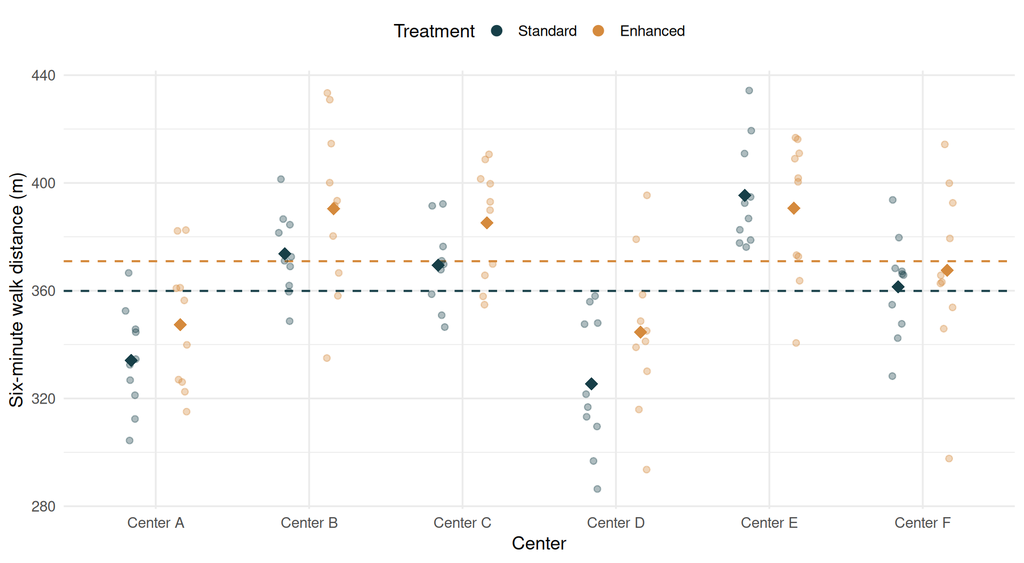

Observed mean walking distance (m)

|  | Standard | Enhanced |
| --- | --- | --- |
| Center A | 334.13 | 347.37 |
| Center B | 373.69 | 390.40 |
| Center C | 369.46 | 385.17 |
| Center D | 325.39 | 344.66 |
| Center E | 395.40 | 390.54 |
| Center F | 361.41 | 367.52 |

Yes: the center differences are substantial relative to the variation among patients. The standard-care means range from 325.39 m in Center D to 395.40 m in Center E, a difference of 70.01 m. Enhanced-care means range from 344.66 m in Center D to 390.54 m in Center E, a difference of 45.88 m. Centers A and D tend to have lower outcomes, while B, C and E tend to have higher outcomes.

Within individual center–treatment groups, the observed standard deviations range from about 15 to 33 m. There is overlap among patients, but the shifts in group means are large enough that center should be included in the analysis. The overall means are 359.91 m for standard care and 370.94 m for enhanced care.

# Specify the model and code the factors

## Specify the model

Let $Y_{ij}$ be the outcome for patient $i$ in center $j$, and let $T_{ij}$ indicate the patient’s treatment. We include an intercept $\beta_0$, a treatment coefficient $\beta_1$, and a fixed contribution $c_j$ for each center:

$$Y_{ij} = \beta_0 + \beta_1 T_{ij} + c_j + \varepsilon_{ij},
\qquad \varepsilon_{ij} \overset{\mathrm{iid}}{\sim} N(0,\sigma^2).$$

Without a constraint, increasing the intercept and decreasing every center contribution by the same amount would leave the model’s predictions unchanged. To define these parameters uniquely, we require the six center contributions to sum to zero:

$$c_A+c_B+c_C+c_D+c_E+c_F=0.$$

The model assumes that the expected treatment difference is the same in every center. After accounting for treatment and center, the remaining errors are assumed to be independent and identically distributed Normal variables with mean zero and common variance.

To fit this model in R, we explicitly set how each factor is represented numerically. We use **dummy coding** for treatment to define $T_{ij}$ and **effects coding** for center so that R estimates the center deviations specified above.

## Code treatment using dummy coding

With **dummy coding**, one category is the reference. We use standard care as the reference and represent treatment by a single indicator:

| Treatment | Indicator $T_{ij}$ |
| --- | --- |
| Standard | 0 |
| Enhanced | 1 |

Within center $j$, the expected standard-care outcome is $\beta_0+c_j$, and the expected enhanced-care outcome is $\beta_0+\beta_1+c_j$. The treatment coefficient $\beta_1$ is therefore the enhanced-minus-standard difference.

```r
# The first factor level, Standard, is the reference.
contrasts(rehab$treatment) <- contr.treatment(levels(rehab$treatment))
contrasts(rehab$treatment)
```

`contr.treatment()` creates the dummy-coding matrix. Assigning it with `contrasts()` tells R to use this coding when fitting a model with the treatment factor. Printing the matrix shows how each treatment is represented.

## Code center using effects coding

The sum-to-zero constraint makes each $c_j$ a deviation from the equally weighted average across centers, comparing patients receiving the same treatment. With standard care coded 0, the intercept $\beta_0$ is **the expected standard-care outcome averaged equally across the six centers**. In this balanced trial, equal weighting of centers also agrees with weighting by their patient counts.

We use **effects coding** to estimate these deviations directly. With dummy coding for center instead, the intercept would describe standard care in a reference center, and the other center coefficients would describe differences from that center.

```r
contrasts(rehab$center) <- contr.sum(levels(rehab$center))
contrasts(rehab$center)
```

`contr.sum()` creates the effects-coding matrix. Inspect the result: there are six rows, one per center, but only five columns. Centers A–E each have a 1 in their own column and 0 in the others. Center F has $-1$ in all five columns. Its contribution is therefore minus the sum of the other five contributions. Only five center coefficients are needed because the sum-to-zero constraint determines the sixth.

Changing the center coding changes the interpretation of the intercept and center coefficients. The fitted outcomes, estimated treatment difference and its standard error stay the same. Setting the coding explicitly makes the chosen parameterization reproducible.

# Fit and interpret the model

## Fit the model and read its output

```r
model_fixed <- lm(distance ~ treatment + center, data = rehab)
summary(model_fixed)
```

In an R model formula, the outcome is on the left of `~`, and predictors are on the right. An intercept is included automatically. R uses the coding we assigned to the treatment and center factors.

In the output, `(Intercept)` estimates $\beta_0$, and `treatmentEnhanced` estimates $\beta_1$. The five center coefficients are named `center1` to `center5`, corresponding to Centers A–E. For example, a positive `center1` indicates a higher expected outcome in Center A than the center average, for either treatment. The model-predicted standard-care outcome in Center A is the intercept plus `center1`.

**ImportantQuestion 3**

Interpret the intercept, the treatment coefficient, and `center1`. How would you recover the contribution for Center F? Why would the intercept have a different interpretation if we used dummy coding for center?

**TipModel answer 3**

```
Call:
lm(formula = distance ~ treatment + center, data = rehab)

Residuals:
    Min      1Q  Median      3Q     Max
-72.280 -16.212  -0.645  16.969  54.860

Coefficients:
                  Estimate Std. Error t value Pr(>|t|)
(Intercept)        359.913      3.068 117.312  < 2e-16 ***
treatmentEnhanced   11.030      4.339   2.542 0.012370 *
center1            -24.678      4.851  -5.087 1.46e-06 ***
center2             16.617      4.851   3.425 0.000856 ***
center3             11.887      4.851   2.450 0.015804 *
center4            -30.403      4.851  -6.268 6.88e-09 ***
center5             27.542      4.851   5.678 1.07e-07 ***
---
Signif. codes:  0 '***' 0.001 '**' 0.01 '*' 0.05 '.' 0.1 ' ' 1

Residual standard error: 23.76 on 113 degrees of freedom
Multiple R-squared:  0.4755,    Adjusted R-squared:  0.4476
F-statistic: 17.07 on 6 and 113 DF,  p-value: 5.787e-14
```

- Intercept: 359.91 m. This is the estimated expected walking distance for standard care, averaged equally across the six centers.
- Treatment coefficient: 11.03 m. Within any given center, enhanced care is estimated to increase the expected walking distance by 11.03 m compared with standard care. The additive model assumes this expected difference is the same in all six centers.
- `center1`: -24.68 m. Center A’s expected outcome is 24.68 m below the equally weighted center average, for either treatment. Its fitted standard-care mean is 335.24 m; its fitted enhanced-care mean is 346.27 m.

Recover Center F using the sum-to-zero constraint:

$$\widehat c_F = -(\widehat c_A+\widehat c_B+\widehat c_C+\widehat c_D+\widehat c_E)
= -0.96\text{ m}.$$

In R, use `-sum(coef(model_fixed)[paste0("center", 1:5)])`. Use the unrounded coefficients in this calculation.

| Center | Estimated contribution (m) |
| --- | --- |
| Center A | -24.68 |
| Center B | 16.62 |
| Center C | 11.89 |
| Center D | -30.40 |
| Center E | 27.54 |
| Center F | -0.96 |

With dummy coding for center and Center A as the reference, the intercept would instead be the fitted standard-care mean in Center A, 335.24 m. Center coefficients would compare each other center with A. The fitted values, treatment estimate and its standard error would stay the same.

## Treatment effect and uncertainty

In `summary(model_fixed)`, the row `treatmentEnhanced` gives the estimated enhanced-minus-standard difference, its standard error, and a test against a zero difference. The residual standard error at the bottom of the output estimates the individual-error standard deviation after accounting for treatment and center.

Use `confint()` to obtain the 95% confidence interval for the treatment coefficient, and `sigma()` to extract the residual standard deviation.

```r
confint(model_fixed, "treatmentEnhanced")
sigma(model_fixed)
```

The standard error of the treatment coefficient describes uncertainty about the estimated treatment difference. The residual standard deviation describes the remaining variation in individual walking distances. Both are expressed in meters.

**ImportantQuestion 4**

What are the estimated enhanced-minus-standard difference, its standard error, and its 95% confidence interval? What is the residual standard deviation, and how does its interpretation differ from that of the treatment coefficient’s standard error?

**TipModel answer 4**

| Quantity | Value (m) |
| --- | --- |
| Enhanced minus standard | 11.03 |
| Standard error of treatment estimate | 4.34 |
| 95% CI: lower limit | 2.43 |
| 95% CI: upper limit | 19.63 |
| Residual standard deviation | 23.76 |

After accounting for center, enhanced care is estimated to improve mean walking distance by 11.03 m. The 95% confidence interval is 2.43 to 19.63 m. It excludes zero, consistent with the two-sided test in the model output ($t = 2.54$, 113 residual degrees of freedom, $p = 0.0124$). Under the model assumptions, the data support a positive average treatment effect. Assessing the practical importance of this improvement requires a relevant clinical benchmark.

The standard error of 4.34 m measures the sampling uncertainty in the estimated treatment difference. The residual standard deviation of 23.76 m measures the remaining variation in individual patient outcomes around their fitted treatment-and-center means.

# Check the model assumptions

As in ordinary linear regression, residual plots help assess whether the error distribution and variance assumptions are plausible.

```r
plot(model_fixed, which = 1)  # Residuals versus fitted values
plot(model_fixed, which = 2)  # Normal Q-Q plot
```

The first plot can reveal changes in residual spread or patterns left in the mean. The second compares the residual distribution with a Normal distribution. Residuals are calculated from the fitted model; they are estimates of the unobserved errors.

**ImportantQuestion 5**

Do these plots suggest clear violations of the Normality or constant-variance assumptions? Describe the patterns that support your answer.

**TipModel answer 5**

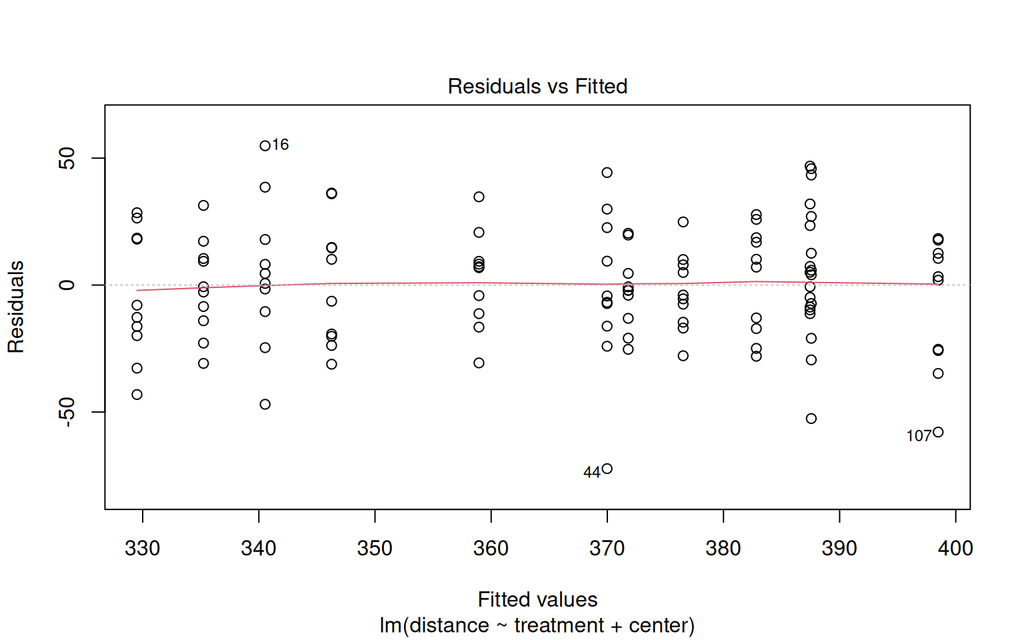

Residuals versus fitted values: residuals are scattered around zero, with a nearly horizontal smooth and no clear funnel. This suggests no strong change in variance with the fitted mean. The vertical bands occur because patients in the same center–treatment group share a fitted value.

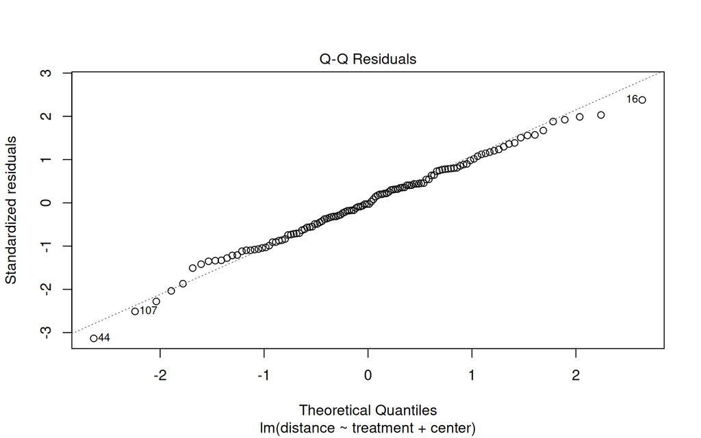

Normal Q–Q plot: most points follow the reference line, with modest tail departures, particularly observations 44 and 107. Normality appears reasonable.